# TP statistiques univariées

26 février 2026

## Statistiques descriptives

## Données

[Enquête de vie 2003](https://www.insee.fr/fr/statistiques/2532244) de l’INSEE

```r
library("questionr")
data(hdv2003)
```

Afficher les tableaux avec `View()`

## Moyenne, écart-type, médiane

Statistiques sur l’âge des personnes interrogées

```r
mean(hdv2003$age)
```

```
## [1] 48.157
```

```r
sd(hdv2003$age)
```

```
## [1] 16.94181
```

```r
var(hdv2003$age)
```

```
## [1] 287.0249
```

```r
median(hdv2003$age)
```

```
## [1] 48
```

## Histogramme

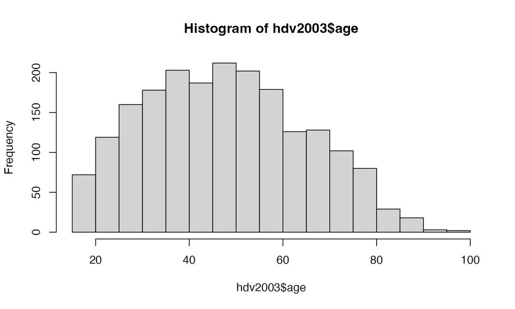

```r
hist(hdv2003$age)
```

## Densité de probabilité

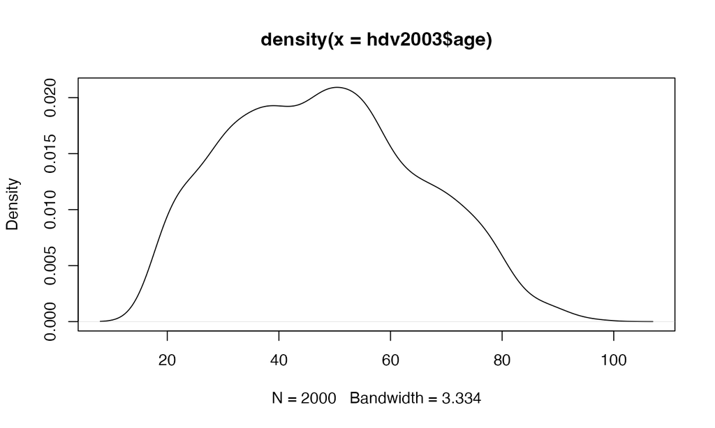

```r
plot(density(hdv2003$age))
```

## Densité sans réflexion

La densité n’est pas bornée

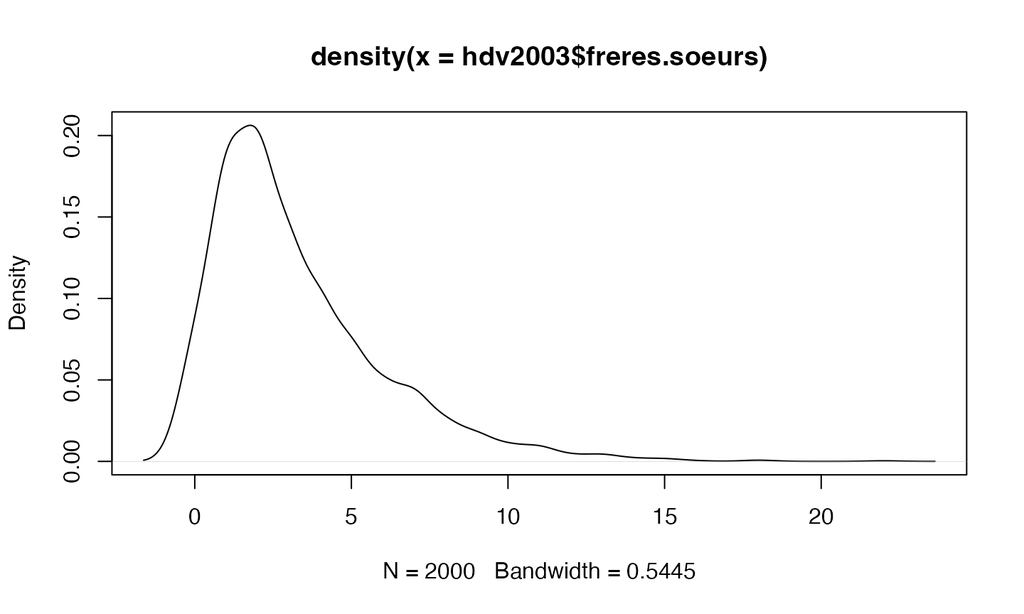

```r
plot(density(hdv2003$freres.soeurs))
```

## Densité avec réflexion

Utiliser le package *GoFKernel*

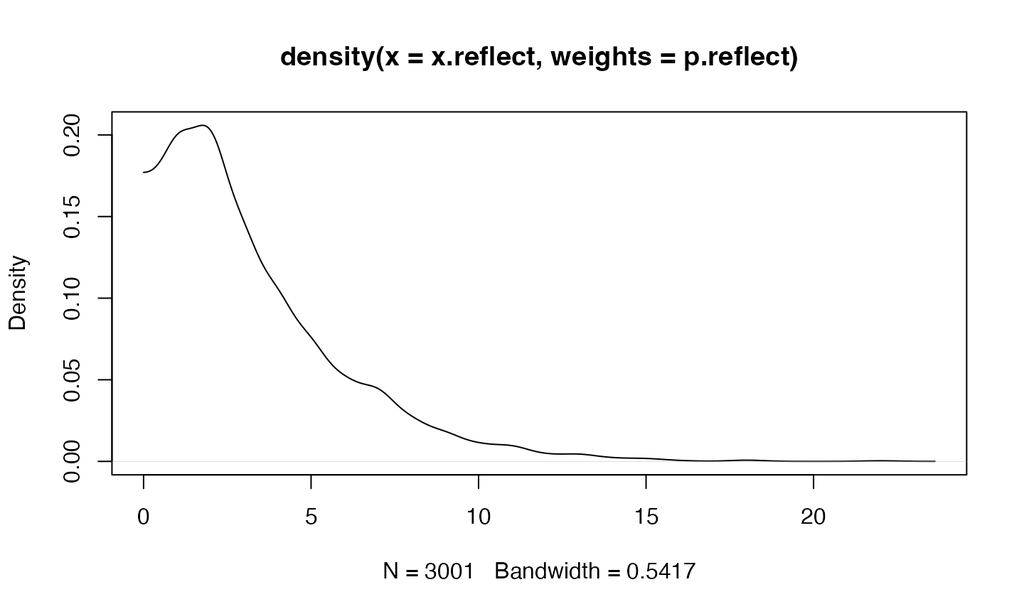

```r
library("GoFKernel")
plot(
  density.reflected(hdv2003$freres.soeurs, lower = 0)
)
```

## Histogramme lissé

Histogramme des probabilités

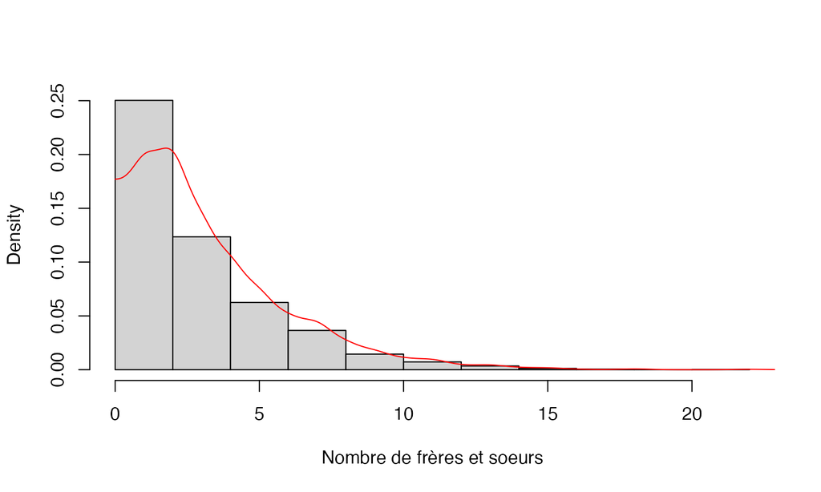

```r
hist(
  hdv2003$freres.soeurs,
  prob = TRUE,
  main = "",
  xlab = "Nombre de frères et soeurs"
)
lines(
  density.reflected(hdv2003$freres.soeurs, lower = 0),
  col = "red"
)
```

## Quantiles

```r
summary(hdv2003$age)
```

```
##    Min. 1st Qu.  Median    Mean 3rd Qu.    Max.
##   18.00   35.00   48.00   48.16   60.00   97.00
```

```r
quantile(hdv2003$age, probs = c(0.025, 0.975))
```

```
##  2.5% 97.5%
##    20    81
```

## Boîte à moustaches

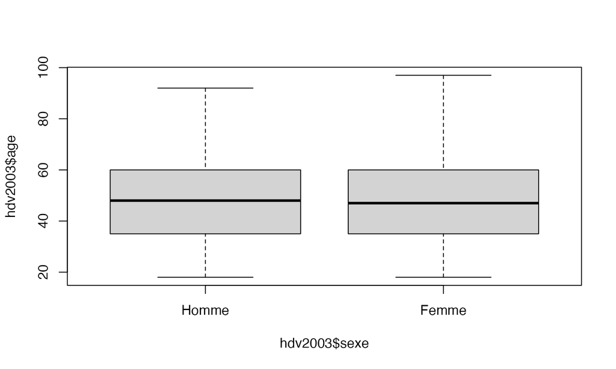

```r
boxplot(hdv2003$age ~ hdv2003$sexe)
```

## Comptages

Pour les variables discrètes.

```r
table(hdv2003$sexe)
```

```
##
## Homme Femme
##   899  1101
```

## Lois de Probabilités

## Distributions classiques

Incontournables:

- loi uniforme
- loi de Bernoulli, loi binomiale
- loi de Poisson
- loi normale (gaussienne)

## Loi uniforme

Densité de probabilité:

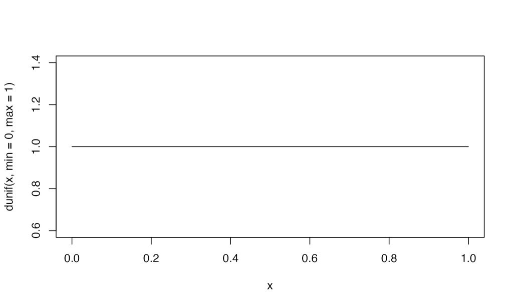

```r
curve(dunif(x, min = 0, max = 1), from = 0, to = 1)
```

## Loi uniforme

Fonction cumulative :

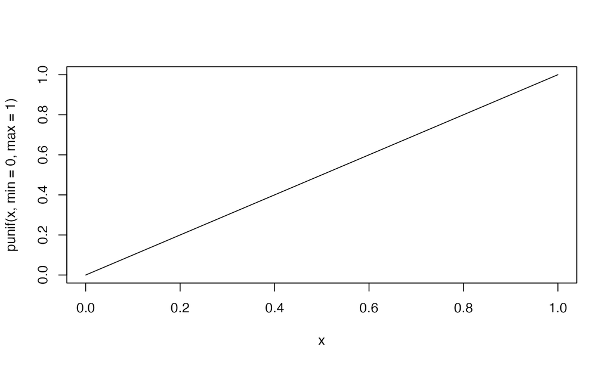

```r
curve(punif(x, min = 0, max = 1), from = 0, to = 1)
```

## Loi uniforme

Fonction quantile:

```r
qunif(p = 0.95, min = 0, max = 2)
```

```
## [1] 1.9
```

## Loi uniforme

Tirage:

```r
runif(n = 5)
```

```
## [1] 0.0482511 0.2186699 0.5021846 0.4053148
## [5] 0.3986500
```

Toutes les distributions de probabilité ont des fonctions `d`, `p`, `q` et `r`.

## Loi des grands nombres

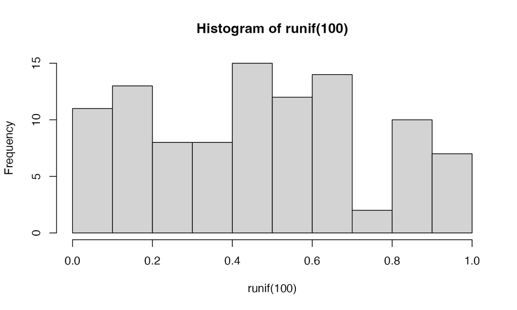

```r
hist(runif(100))
```

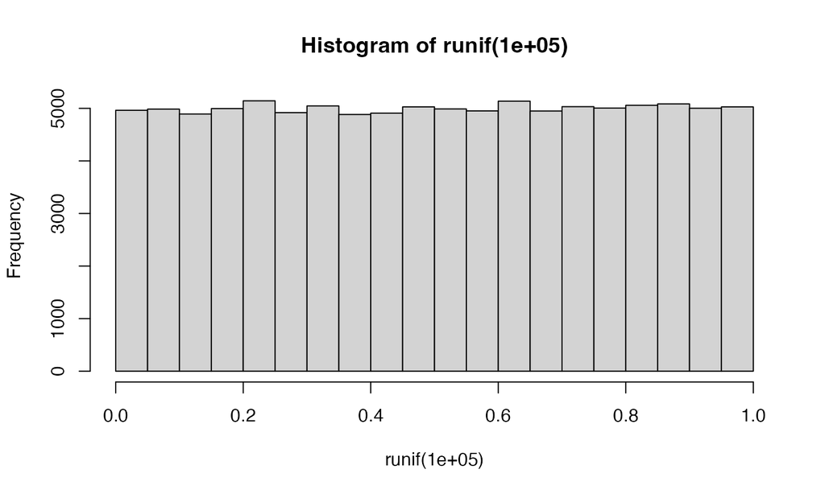

```r
hist(runif(100000))
```

La distribution des tirages tend vers la loi quand le nombre de tirages augmente.

## Loi des grands nombres

La moyenne tend aussi vers l’espérance:

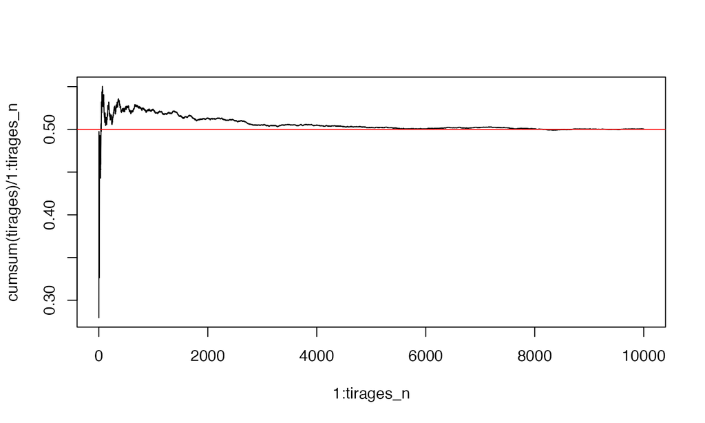

```r
tirages_n <- 10000
tirages <- runif(tirages_n)
plot(x = 1:tirages_n, y = cumsum(tirages) / 1:tirages_n, type = "l")
abline(h = 0.5, col = "red")
```

## Loi binomiale

Nombre de succès d’une épreuve répétée `size` fois avec la probabilité de succès `prob`.

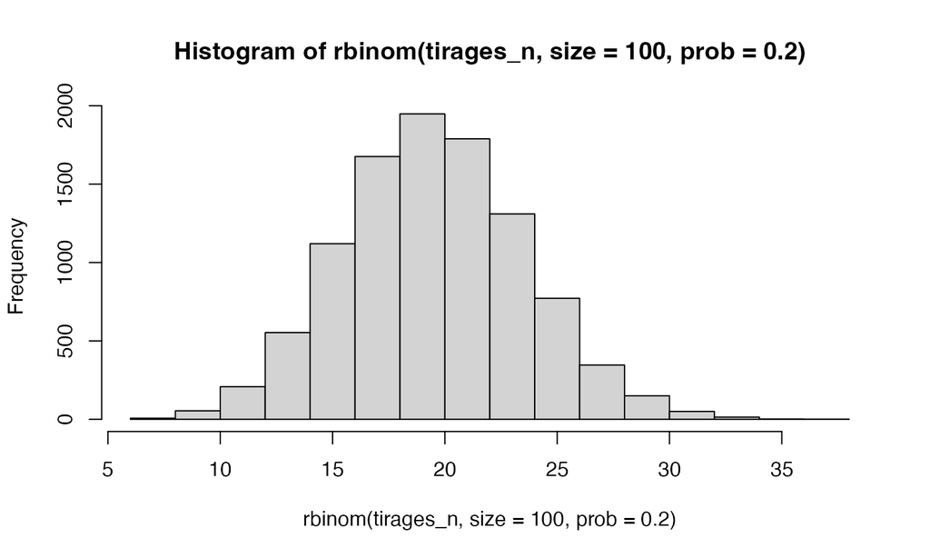

```r
hist(rbinom(tirages_n, size = 100, prob = 0.2))
```

## Loi de Poisson

Loi binomiale dont la probabilité de succès tend vers 0 et le nombre d’épreuves vers \(+\infty\).

Ex.: combien d’arbres se trouvent dans 1000 m² de forêt avec une densité de 500/ha?

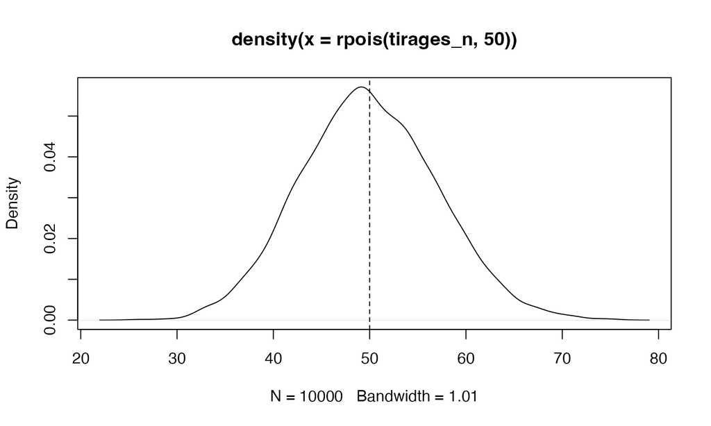

```r
# 10000 tirages, espérance = 500 * 0.1
plot(density(rpois(tirages_n, 50)))
abline(v = 50, lty = 2)
```

## Loi normale

Distribution de la moyenne de nombreuses variables aléatoires.

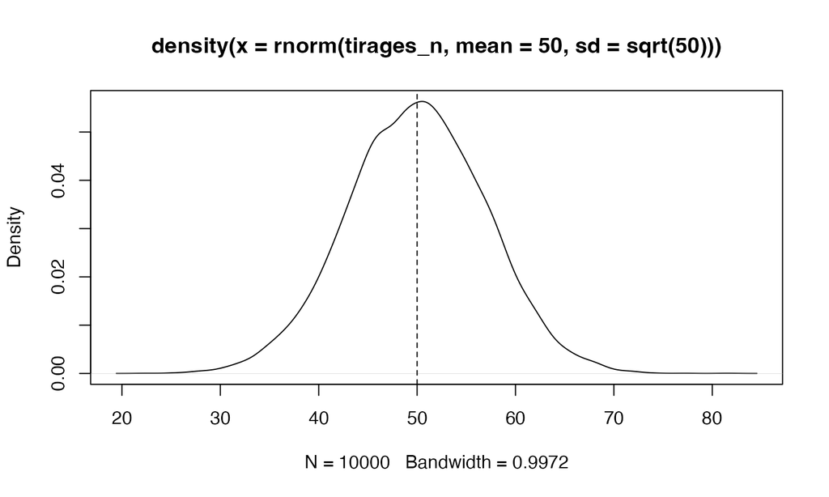

```r
# 10000 tirages, espérance = 500 * 0.1
plot(density(rnorm(tirages_n, mean = 50, sd = sqrt(50))))
abline(v = 50, lty = 2)
```

A comparer avec la loi de Poisson

## Loi log-normale

Loi dont le logarithme est normal.

Distribution du produit de nombreuses variables aléatoires.

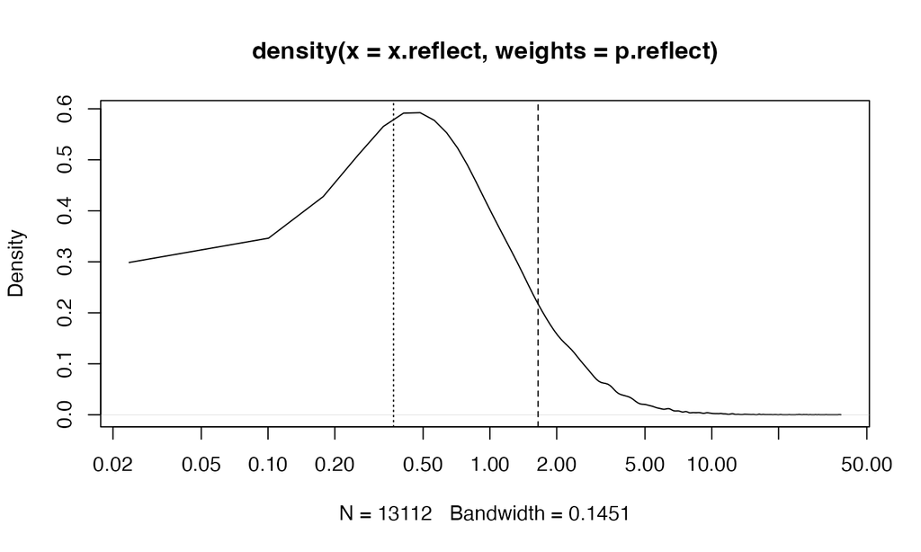

```r
plot(
  density.reflected(rlnorm(tirages_n, meanlog = 0, sdlog = 1), lower = 0),
  log ="x"
)
abline(v = exp(1/2), lty = 2)  # Espérance
abline(v = exp(-1), lty = 3)   # Mode
```

## Théorème de la limite centrale

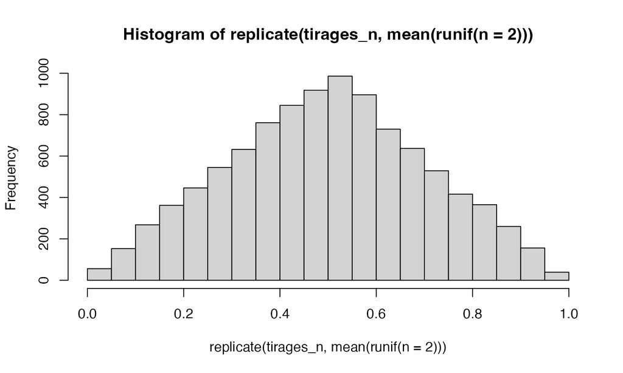

```r
hist(
  replicate(
    tirages_n,
    mean(runif(n = 2))
  )
)
```

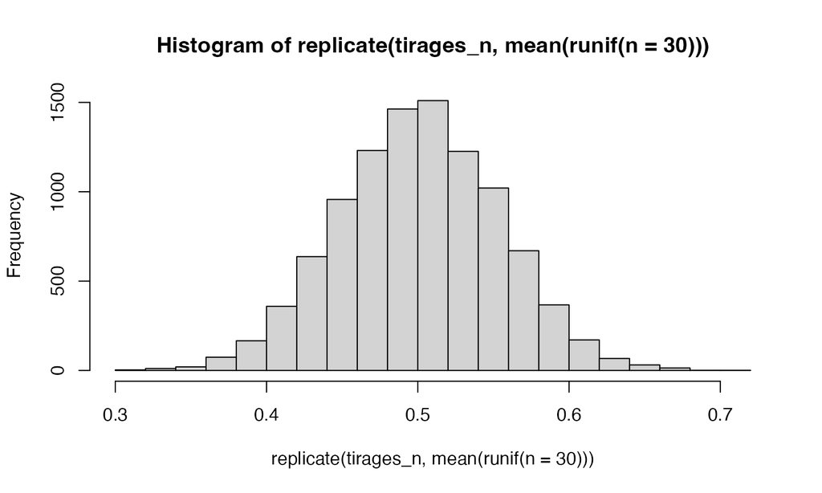

```r
hist(
  replicate(
    tirages_n,
    mean(runif(n = 30))
  )
)
```

La distribution de la moyenne de \(n\) variables uniformes tend vers la loi normale. Sa variance est celle de la loi uniforme (\(1/12\)) divisée par \(n\).

## Intervalle de confiance

\(\alpha\) est le seuil de risque, en général 5%.

\(1 - \alpha\) est le seuil de confiance, en général 95%.

95% des **tirages** d’une loi normale sont situés à moins de 1.96 écarts-types (\(\sigma\)) de l’espérance.

```r
qnorm(0.975)
```

```
## [1] 1.959964
```

## Intervalle de confiance

La **moyenne** de \(n\) variables aléatoires tend vers une loi normale.

95% de ses réalisations sont situés à moins de \(1,96 \sigma / \sqrt{n}\) de l’espérance.

Précisément 1,96 est le 97,5ème centile de la loi de Student avec un très grand nombre de degrés de liberté.

```r
alpha <- 0.05
qt(1 - alpha / 2, df = 1E6)
```

```
## [1] 1.959966
```

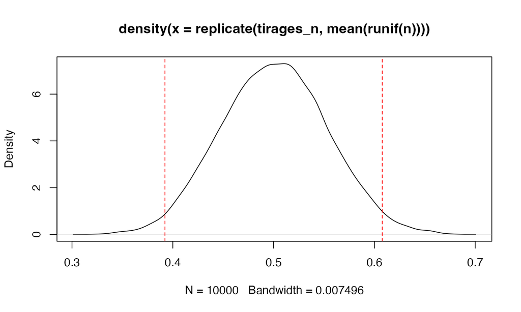

```r
n = 30
plot(density(
  replicate(
    tirages_n,
    mean(runif(n))
  )
))
ci <- qt(1-alpha/2, df = n - 1) /
  sqrt(12) / sqrt(n)
abline(v = 0.5 + c(ci, -ci),
       col = "red", lty = 2)
```

## Test contre une valeur

Combien de temps regarde-t-on la TV par jour ?

```r
(tv_mean <- mean(hdv2003$heures.tv, na.rm = TRUE))
```

```
## [1] 2.246566
```

\(n\) mesures individuelles, loi inconnue. La moyenne tend vers une loi normale.

```r
n <- sum(!is.na(hdv2003$heures.tv))
tv_sd <- sd(hdv2003$heures.tv, na.rm = TRUE)
ci <- qt(1 - alpha / 2, df = n - 1) * tv_sd / sqrt(n)
paste("Intervalle de confiance:", tv_mean - ci, "-", tv_mean + ci)
```

```
## [1] "Intervalle de confiance: 2.16859286989944 - 2.32453996218076"
```

On regarde la TV plus de 2 heures par jour (95% de confiance).

## Méthode de Monte-Carlo

Si la loi est inconnue mais l’algorithme de simulation disponible.

Exemple : carré d’une distribution normale.

```r
dist <- rnorm(tirages_n)^2
(dist_q <- quantile(dist, c(0.025, 0.975)))
```

```
##        2.5%       97.5%
## 0.001017103 5.249021141
```

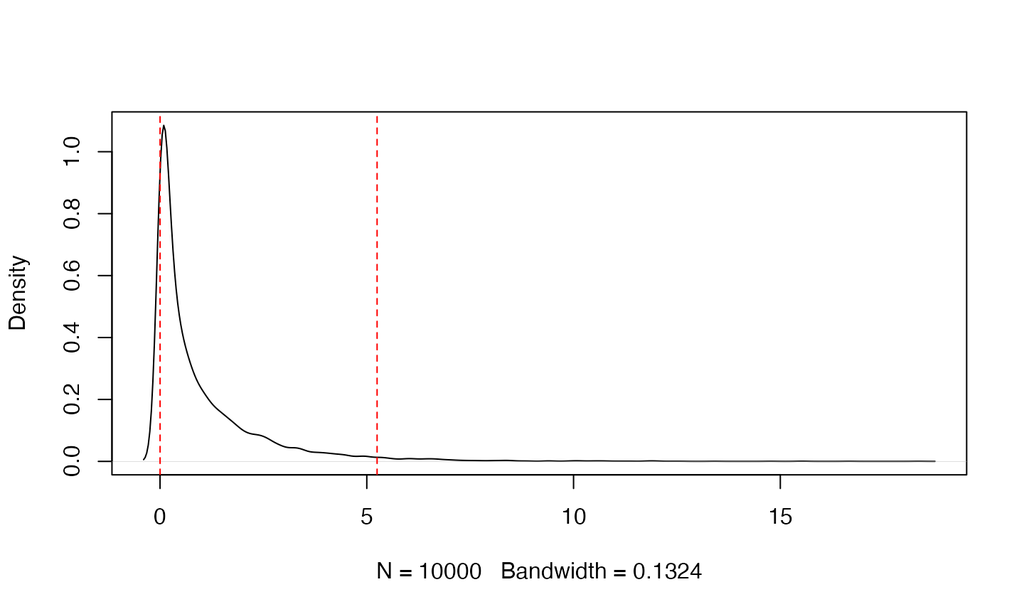

```r
plot(density(dist), main = "")
abline(v = dist_q, col = "red", lty = 2)
```

## Méthode de Monte-Carlo

… mais on connaît souvent les distributions.

Le carré d’une loi normale est une loi du \(\chi^2\) à 1 degré de liberté, identique à une loi \(\Gamma\) de forme \(1/2\) et d’échelle \(2\).

```r
qchisq(.075, df = 1)
```

```
## [1] 0.008861853
```

```r
qchisq(.975, df = 1)
```

```
## [1] 5.023886
```

```r
qgamma(0.975, shape = 1/2, scale = 2)
```

```
## [1] 5.023886
```

\(\to\) lire l’aide `?qchisq`, Wikipedia, Google…